# تقرير السيناريوهات - بالاعتماد علي تنقيب البيانات والطرق الاحصائية

## السيناريوهات التي تعتمد علي فكرة التجميع (Clustering) للمناطق والادارات والمقاولين

الفكرة العامة: استخدام المتغيرات المهمة خاصة عدد المشاريع وقيمة المشاريع لتقسيم المناطق والادارات والمقاولين الي مجموعات

### التجميع (Clustering) للمناطق

لتقسيم المناطق الي مجموعات بناء علي عدد وقيم المشاريع، نبدأ الاول برسم شكل الانتشار لعدد وقيمة المشاريع علي مستوي المناطق المختلفة كالتالي:

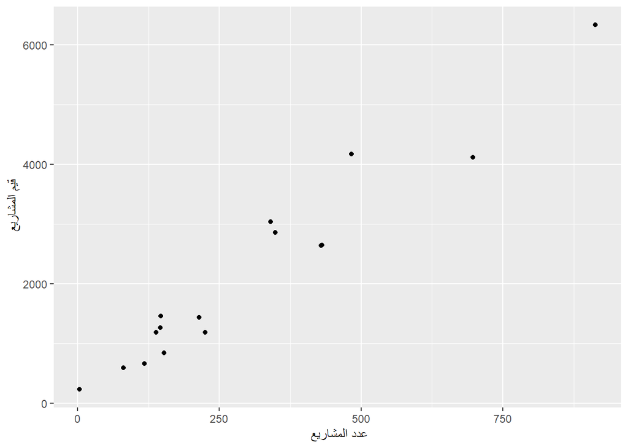

يتضح من هذا الشكل أن المناطق ذات عدد المشاريع الاقل فهي ايضا ذات قيم مشاريع أقل والعكس بالعكس، كذلك يتضح بشكل كبير يمكن تقسيم المناطق الي ثلاثة مجموعات:

- المجموعة الدنيا: ذات عدد وقيم مشاريع صغيرة وهي تضم تقريبا 9 مناطق.
- المجموعة المتوسطة: ذات عدد وقيم مشاريع متوسطة وهي تضم تقريبا 5 مناطق.
- المجموعة العليا: ذات عدد وقيم مشاريع كبيرة وهي تضم تقريبا منطقتين فقط.

لتوضيح ذلك بشكل أكثر قمنا بتلوين المجموعات وفقا لكل مجموعة في الشكل السابق لنحصل علي الشكل التالي:

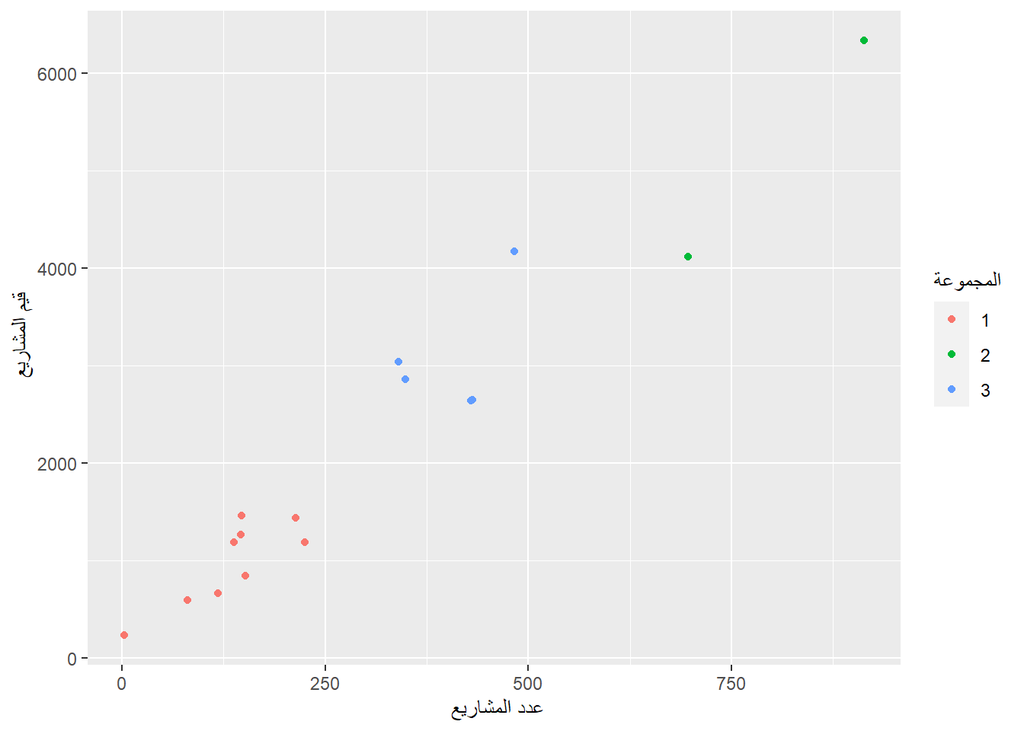

فيما يلي نتائج طرق تنقيب البيانات التي تؤكد فكرة التقسيم الي 3 مجموعات (لاحقا سيتم شرح تفاصيل الطرق المستخدمة)

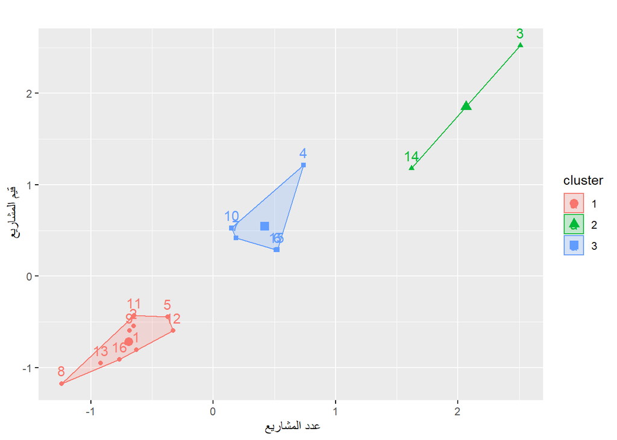

| reg_name | number_projects | sum_value | Group |
| --- | --- | --- | --- |
| الباحة | 152 | 840.3 | 1 |
| الجوف | 146 | 1262.9 | 1 |
| الرياض | 913 | 6333.3 | 2 |
| الشرقية | 483 | 4169.9 | 3 |
| الطائف | 214 | 1434.4 | 1 |
| القصيم | 431 | 2643.3 | 3 |
| المدينة المنورة | 349 | 2856.7 | 3 |
| الوكالة | 3 | 227.9 | 1 |
| تبوك | 138 | 1183.1 | 1 |
| جازان | 340 | 3034.0 | 3 |
| جدة | 147 | 1460.0 | 1 |
| حائل | 225 | 1185.9 | 1 |
| حدود شمالية | 81 | 592.4 | 1 |
| عسير | 697 | 4112.2 | 2 |
| مكة المكرمة | 429 | 2640.7 | 3 |
| نجران | 118 | 658.6 | 1 |

### التجميع (Clustering) للادارات

لتقسيم الادارات التعليمية الي مجموعات بناء علي عدد وقيم المشاريع، نبدأ الاول برسم شكل الانتشار لعدد وقيمة المشاريع علي مستوي الادارات التعليمية المختلفة كالتالي:

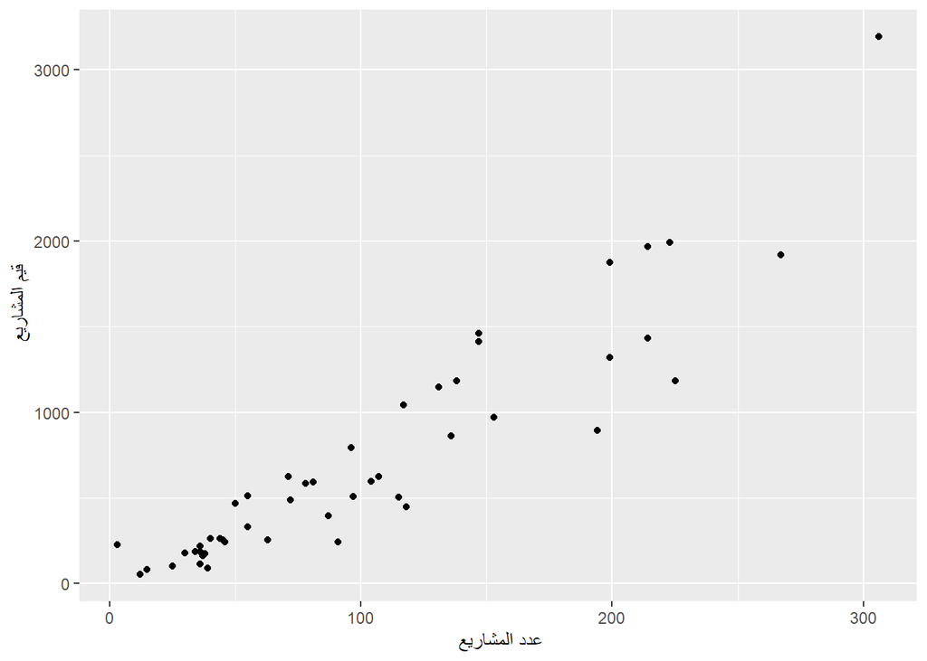

يتضح من هذا الشكل أن الادارات التعليمية ذات عدد المشاريع الاقل فهي ايضا ذات قيم مشاريع أقل والعكس بالعكس، كذلك يتضح بشكل كبير يمكن تقسيم الادارات التعليمية الي ثلاثة مجموعات:

- المجموعة الدنيا: ذات عدد وقيم مشاريع صغيرة وهي تضم تقريبا 32 ادارة تعليمية.
- المجموعة المتوسطة: ذات عدد وقيم مشاريع متوسطة وهي تضم تقريبا 11 ادارة تعليمية.
- المجموعة العليا: ذات عدد وقيم مشاريع كبيرة وهي تضم تقريبا 5 ادارات تعليمية فقط.

لتوضيح ذلك بشكل أكثر قمنا بتلوين المجموعات وفقا لكل مجموعة في الشكل السابق لنحصل علي الشكل التالي:

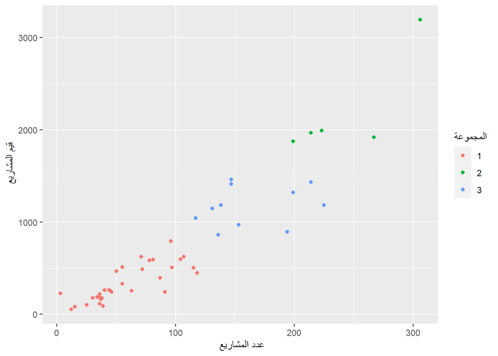

فيما يلي نتائج طرق تنقيب البيانات التي تؤكد فكرة التقسيم الي 3 مجموعات (لاحقا سيتم شرح تفاصيل الطرق المستخدمة)

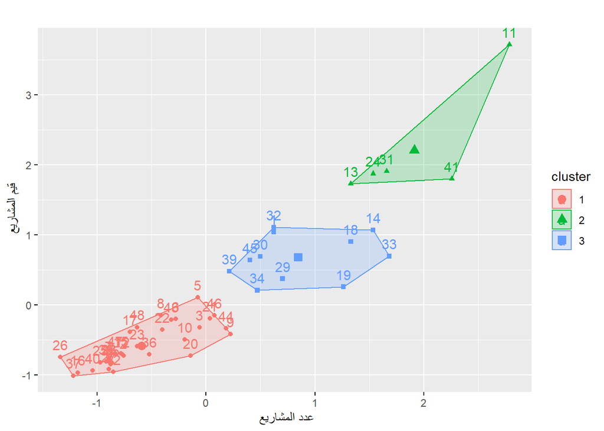

| area_name | number_projects | sum_value | Group |
| --- | --- | --- | --- |
| الأحساء | 147 | 1414.6 | 3 |
| الأفلاج | 46 | 243.1 | 1 |
| الباحة | 97 | 508.5 | 1 |
| البكيرية | 37 | 162.6 | 1 |
| الجوف | 96 | 795.6 | 1 |
| الحدود الشمالية | 81 | 592.4 | 1 |
| الحوطة والحريق | 36 | 217.9 | 1 |
| الخرج | 71 | 625.5 | 1 |
| الدوادمي | 118 | 446.7 | 1 |
| الرس | 87 | 394.4 | 1 |
| الرياض | 306 | 3193.9 | 2 |
| الزلفي | 45 | 256.0 | 1 |
| الشرقية | 199 | 1874.1 | 2 |
| الطائف | 214 | 1434.4 | 3 |
| العلا | 44 | 262.9 | 1 |
| الغاط | 15 | 82.3 | 1 |
| القريات | 50 | 467.3 | 1 |
| القصيم | 199 | 1322.4 | 3 |
| القنفذة | 194 | 894.9 | 3 |
| القويعية | 91 | 241.1 | 1 |
| الليث | 104 | 596.7 | 1 |
| المجمعة | 72 | 487.9 | 1 |
| المخواة | 55 | 331.8 | 1 |
| المدينة المنورة | 214 | 1968.3 | 2 |
| المذنب | 30 | 179.4 | 1 |
| المشاريع المركزية | 3 | 227.9 | 1 |
| المهد | 36 | 113.0 | 1 |
| النماص | 36 | 188.5 | 1 |
| بيشة | 153 | 971.6 | 3 |
| تبوك | 138 | 1183.1 | 3 |
| جازان | 223 | 1992.2 | 2 |
| جدة | 147 | 1460.0 | 3 |
| حائل | 225 | 1185.9 | 3 |
| حفر الباطن | 136 | 861.8 | 3 |
| رجال ألمع | 38 | 173.8 | 1 |
| سراة عبيدة | 63 | 254.0 | 1 |
| شرورة | 12 | 52.6 | 1 |
| شقراء | 34 | 185.3 | 1 |
| صبياء | 117 | 1041.8 | 3 |
| ظهران الجنوب | 25 | 101.8 | 1 |
| عسير | 267 | 1920.0 | 2 |
| عفيف | 39 | 89.2 | 1 |
| عنيزة | 78 | 584.6 | 1 |
| محايل عسير | 115 | 502.6 | 1 |
| مكة المكرمة | 131 | 1149.1 | 3 |
| نجران | 107 | 625.4 | 1 |
| وادى الدواسر | 40 | 264.4 | 1 |
| ينبع | 55 | 512.5 | 1 |

### التجميع (Clustering) للمقاولين

لتقسيم المقاولين الي مجموعات بناء علي عدد وقيم المشاريع، نبدأ الاول برسم شكل الانتشار لعدد وقيمة المشاريع علي مستوي المقاولين كالتالي:

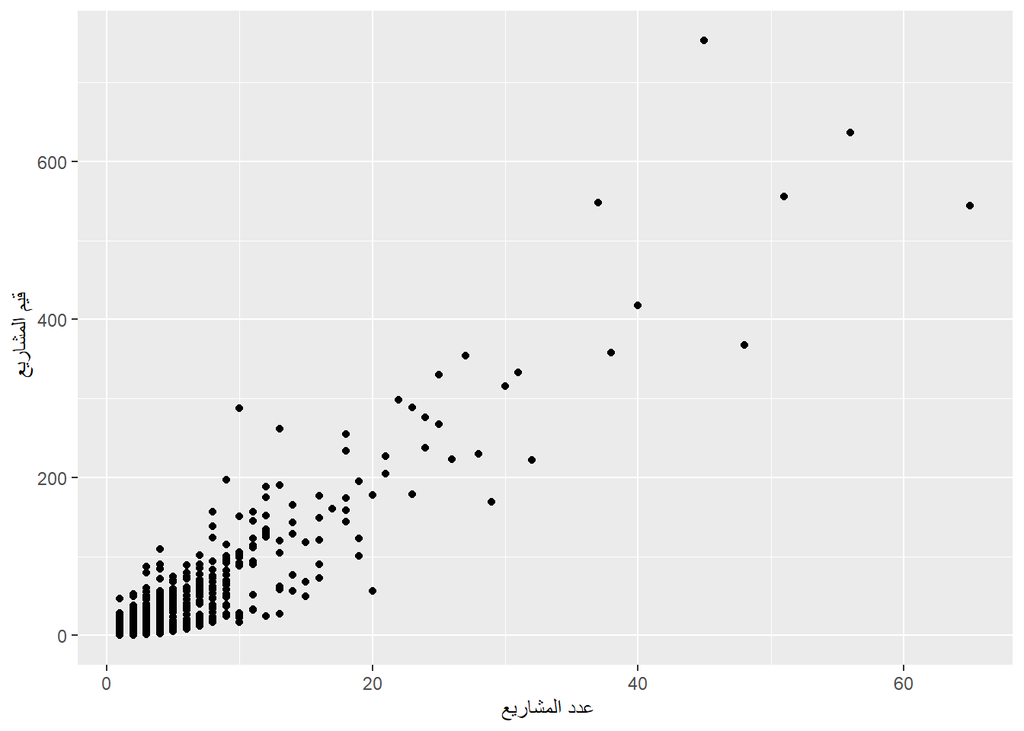

يتضح من هذا الشكل أن المقاولون اصحاب اعداد المشاريع الاقل فهم ايضا اصحاب قيم مشاريع أقل والعكس بالعكس، كذلك يتضح بشكل كبير يمكن تقسيم المقاولين الي ثلاثة مجموعات:

لتوضيح ذلك بشكل أكثر قمنا بتلوين المجموعات وفقا لكل مجموعة في الشكل السابق لنحصل علي الشكل التالي:

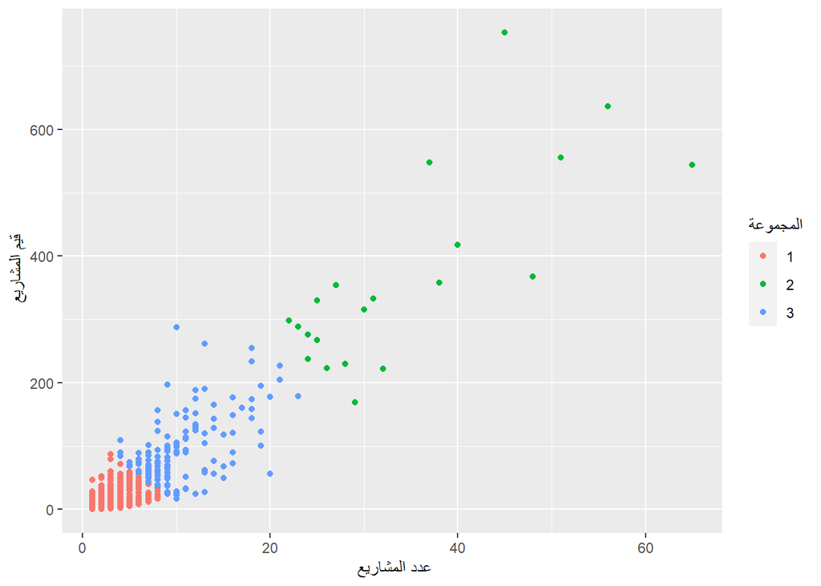

فيما يلي نتائج طرق تنقيب البيانات التي تؤكد فكرة التقسيم الي 3 مجموعات (لاحقا سيتم شرح تفاصيل الطرق المستخدمة)

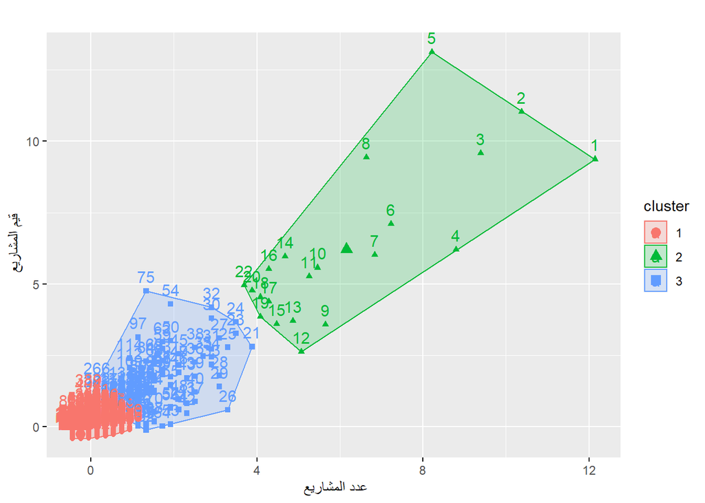

| cont_name | number_projects | sum_value | Group |
| --- | --- | --- | --- |
| شركة المقاول العربي | 166 | 1826.3 | 2 |
| مؤسسة نوادر العمران للمقاولات | 65 | 543.9 | 2 |
| شركة الراجحي للتنمية المحدودة | 56 | 636.1 | 2 |
| مؤسسة عبيد علي السلمي للمقاولات | 51 | 555.8 | 2 |
| شركة بكين الإمارات الدولية للإنشاءات | 48 | 367.8 | 2 |
| شركة ابناء سليمان القضيبي للمقاولات | 45 | 753.0 | 2 |
| شركة الصخور السعودية للتنمية المحدودة | 40 | 418.0 | 2 |
| مؤسسة عبد المحسن الدرسوني للمقاولات | 38 | 357.6 | 2 |
| شركة هاشم للمقاولات والتجارة المحدودة | 37 | 547.4 | 2 |
| مؤسسة راك الجزيرة للمقاولات | 32 | 222.1 | 2 |
| مؤسسة الحفاوة للقاولات | 31 | 332.7 | 2 |
| مؤسسة الافتكار للمقاولات | 30 | 315.9 | 2 |
| مؤسسة جزاع نحيطر الجزاع | 29 | 169.2 | 2 |
| مؤسسة محمد يوسف العجلان للمقاولات | 28 | 229.5 | 2 |
| مؤسسة مؤنس الشايب للمقاولات | 27 | 354.3 | 2 |
| مؤسسة اعمال الارياف للتجارة والمقاولات | 26 | 223.4 | 2 |
| شركة الاعمال التطويرية المحدودة | 25 | 330.3 | 2 |
| مؤسسة المشاريع الهندسية المتقدمة | 25 | 266.9 | 2 |
| شركة الانشاءات الهندسية والتقدم الصناعي (اندكو) | 24 | 275.6 | 2 |
| مؤسسة التاج للتجارة والمقاولات | 24 | 237.4 | 2 |
| شركة العزم للتجارة والمقاولات | 23 | 288.2 | 2 |
| شركة المنزل الماسي المحدودة | 23 | 178.6 | 3 |
| مؤسسة عبدالله مهنا الجمعان للمقاولات | 22 | 298.6 | 2 |
| الشركه السعودية للتشييد | 21 | 204.7 | 3 |
| مؤسسة عبدالله على السلامة | 21 | 227.1 | 3 |
| مؤسسة المنغصي للتجارة والمقاولات | 20 | 177.4 | 3 |
| مؤسسة دوانيق للتجارة والمقاولات | 20 | 55.9 | 3 |
| م/ المشاريع الهندسية الكندية بالتضامن مع ش/ جودت للمقاولات | 19 | 195.3 | 3 |
| مؤسسة بيداء العرب للصيانة والمقاولات | 19 | 122.3 | 3 |
| مؤسسة عبيد مبارك القحطاني للمقاولات العامة | 19 | 100.9 | 3 |

[output cut: 1426 more lines]

## السيناريوهات التي تعتمد علي فكرة فترات الثقة للمتغيرات الكمية المهمة مثل قيمة المشروع - مدة المشروع

### التنبؤ بقيمة المشروع (بالمليون ريال) كقيمة متوقعة مع فترة ثقة 95% علي مستوي كل المشاريع

| expected | lower_interval | uper_interval |
| --- | --- | --- |
| 5.86 | 1.37 | 18.49 |

### التنبؤ بقيمة المشروع كقيمة متوقعة مع فترة ثقة 95% علي مستوي كل منطقة

| reg_name | expected | lower_interval | uper_interval |
| --- | --- | --- | --- |
| الباحة | 3.35 | 1.55 | 13.66 |
| الجوف | 8.73 | 2.08 | 17.00 |
| الرياض | 4.75 | 1.04 | 19.95 |
| الشرقية | 7.64 | 1.58 | 19.55 |
| الطائف | 5.32 | 1.28 | 16.60 |
| القصيم | 4.59 | 1.38 | 15.24 |
| المدينة المنورة | 7.10 | 1.53 | 20.50 |
| الوكالة | 69.96 | 14.15 | 141.99 |
| تبوك | 7.77 | 1.71 | 21.52 |
| جازان | 8.70 | 2.33 | 20.83 |
| جدة | 8.97 | 2.20 | 22.66 |
| حائل | 4.14 | 1.98 | 11.55 |
| حدود شمالية | 6.64 | 1.37 | 19.63 |
| عسير | 3.82 | 1.60 | 13.63 |
| مكة المكرمة | 3.74 | 1.20 | 15.46 |
| نجران | 3.93 | 1.57 | 12.64 |

### التنبؤ بقيمة المشروع كقيمة متوقعة مع فترة ثقة 95% علي مستوي كل ادارة تعليمية

| area_name | expected | lower_interval | uper_interval |
| --- | --- | --- | --- |
| الأحساء | 9.07 | 2.16 | 20.66 |
| الأفلاج | 2.69 | 1.36 | 14.72 |
| الباحة | 3.16 | 1.58 | 13.14 |
| البكيرية | 2.30 | 1.23 | 10.65 |
| الجوف | 8.07 | 2.18 | 17.06 |
| الحدود الشمالية | 6.64 | 1.37 | 19.63 |
| الحوطة والحريق | 3.09 | 1.57 | 15.40 |
| الخرج | 8.77 | 3.34 | 18.23 |
| الدوادمي | 2.42 | 1.53 | 9.39 |
| الرس | 2.38 | 1.55 | 12.16 |
| الرياض | 9.71 | 1.11 | 25.01 |
| الزلفي | 3.29 | 0.28 | 13.70 |
| الشرقية | 8.67 | 1.57 | 20.84 |
| الطائف | 5.32 | 1.28 | 16.60 |
| العلا | 2.64 | 1.44 | 14.43 |
| الغاط | 2.66 | 1.67 | 15.63 |
| القريات | 8.99 | 2.12 | 16.73 |
| القصيم | 5.40 | 1.72 | 17.55 |
| القنفذة | 2.54 | 1.00 | 12.87 |
| القويعية | 2.09 | 0.86 | 5.80 |
| الليث | 3.23 | 1.86 | 11.55 |
| المجمعة | 6.12 | 1.68 | 14.12 |
| المخواة | 4.00 | 1.48 | 13.64 |
| المدينة المنورة | 7.76 | 1.84 | 21.11 |
| المذنب | 2.27 | 1.52 | 18.26 |
| المشاريع المركزية | 69.96 | 14.15 | 141.99 |
| المهد | 2.38 | 1.52 | 7.71 |
| النماص | 3.18 | 1.02 | 14.56 |
| بيشة | 5.80 | 2.32 | 12.41 |
| تبوك | 7.77 | 1.71 | 21.52 |
| جازان | 8.95 | 2.34 | 18.96 |
| جدة | 8.97 | 2.20 | 22.66 |
| حائل | 4.14 | 1.98 | 11.55 |
| حفر الباطن | 6.14 | 1.50 | 12.21 |
| رجال ألمع | 2.98 | 1.32 | 13.27 |
| سراة عبيدة | 2.88 | 1.81 | 9.94 |
| شرورة | 3.92 | 2.16 | 7.82 |
| شقراء | 4.02 | 1.00 | 10.99 |
| صبياء | 7.95 | 2.43 | 21.34 |
| ظهران الجنوب | 2.96 | 2.05 | 7.50 |
| عسير | 6.42 | 1.38 | 15.61 |
| عفيف | 1.95 | 0.68 | 5.80 |
| عنيزة | 6.67 | 1.38 | 12.77 |
| محايل عسير | 2.89 | 1.52 | 10.28 |
| مكة المكرمة | 7.93 | 2.00 | 23.84 |
| نجران | 4.09 | 1.55 | 13.89 |
| وادى الدواسر | 6.17 | 1.17 | 12.65 |
| ينبع | 8.25 | 1.52 | 20.69 |

### التنبؤ بمدة المشروع كقيمة متوقعة مع فترة ثقة 95% علي مستوي كل المشاريع

| expected | lower_interval | uper_interval |
| --- | --- | --- |
| 540 | 270 | 720 |

### التنبؤ بمدة المشروع قيمة متوقعة بفترة ثقة 95% علي مستوي كل منطقة

| reg_name | expected | lower_interval | uper_interval |
| --- | --- | --- | --- |
| الباحة | 450 | 286.5 | 720 |
| الجوف | 630 | 360.0 | 720 |
| الرياض | 540 | 240.0 | 720 |
| الشرقية | 630 | 330.0 | 720 |
| الطائف | 540 | 180.0 | 767 |
| القصيم | 540 | 300.0 | 720 |
| المدينة المنورة | 630 | 300.0 | 810 |
| الوكالة | 600 | 114.0 | 708 |
| تبوك | 600 | 270.0 | 720 |
| جازان | 630 | 320.0 | 720 |
| جدة | 720 | 300.0 | 780 |
| حائل | 540 | 271.5 | 720 |
| حدود شمالية | 600 | 320.0 | 720 |
| عسير | 540 | 299.2 | 720 |
| مكة المكرمة | 450 | 213.0 | 720 |
| نجران | 630 | 396.0 | 720 |

### التنبؤ بمدة المشروع قيمة متوقعة بفترة ثقة 95% علي مستوي كل ادارة تعليمية

| area_name | expected | lower_interval | uper_interval |
| --- | --- | --- | --- |
| الأحساء | 660.0 | 378.00 | 720.00 |
| الأفلاج | 420.0 | 313.25 | 720.00 |
| الباحة | 450.0 | 240.00 | 720.00 |
| البكيرية | 450.0 | 288.00 | 720.00 |
| الجوف | 615.0 | 360.00 | 720.00 |
| الحدود الشمالية | 600.0 | 320.00 | 720.00 |
| الحوطة والحريق | 450.0 | 345.50 | 720.00 |
| الخرج | 630.0 | 330.50 | 750.00 |
| الدوادمي | 450.0 | 320.00 | 720.00 |
| الرس | 442.0 | 306.00 | 720.00 |
| الرياض | 720.0 | 240.00 | 810.00 |
| الزلفي | 450.0 | 186.00 | 720.00 |
| الشرقية | 630.0 | 240.00 | 810.00 |
| الطائف | 540.0 | 180.00 | 767.00 |
| العلا | 450.0 | 184.50 | 999.95 |
| الغاط | 540.0 | 243.00 | 720.00 |
| القريات | 630.0 | 360.00 | 720.00 |
| القصيم | 540.0 | 292.50 | 720.00 |
| القنفذة | 420.0 | 150.00 | 720.00 |
| القويعية | 350.0 | 180.00 | 540.00 |
| الليث | 450.0 | 300.00 | 720.00 |
| المجمعة | 630.0 | 300.00 | 720.00 |
| المخواة | 450.0 | 300.00 | 720.00 |
| المدينة المنورة | 660.0 | 313.00 | 810.00 |
| المذنب | 457.5 | 320.00 | 720.00 |
| المشاريع المركزية | 600.0 | 114.00 | 708.00 |
| المهد | 420.0 | 315.00 | 630.00 |
| النماص | 450.0 | 280.00 | 720.00 |
| بيشة | 540.0 | 360.00 | 720.00 |
| تبوك | 600.0 | 270.00 | 720.00 |
| جازان | 630.0 | 323.30 | 720.00 |
| جدة | 720.0 | 300.00 | 780.00 |
| حائل | 540.0 | 271.50 | 720.00 |
| حفر الباطن | 600.0 | 330.00 | 720.00 |
| رجال ألمع | 450.0 | 320.00 | 720.00 |
| سراة عبيدة | 360.0 | 320.00 | 720.00 |
| شرورة | 540.0 | 312.00 | 660.00 |
| شقراء | 480.0 | 159.00 | 720.00 |
| صبياء | 630.0 | 352.00 | 720.00 |
| ظهران الجنوب | 450.0 | 354.40 | 540.00 |
| عسير | 600.0 | 306.00 | 810.00 |
| عفيف | 360.0 | 180.00 | 468.00 |
| عنيزة | 600.0 | 351.00 | 720.00 |
| محايل عسير | 450.0 | 294.00 | 720.00 |
| مكة المكرمة | 630.0 | 300.00 | 720.00 |
| نجران | 630.0 | 421.05 | 720.00 |
| وادى الدواسر | 540.0 | 296.80 | 720.00 |
| ينبع | 660.0 | 261.00 | 810.00 |

## السيناريوهات

شكل الانتشار بين مدة المشروع وقيمة المشروع في الشكل التالي:

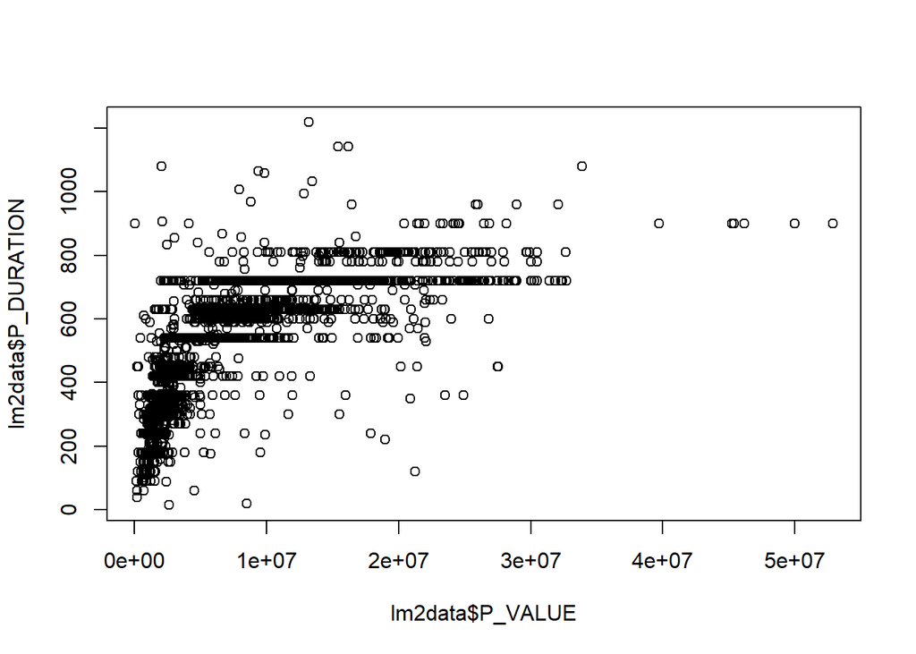

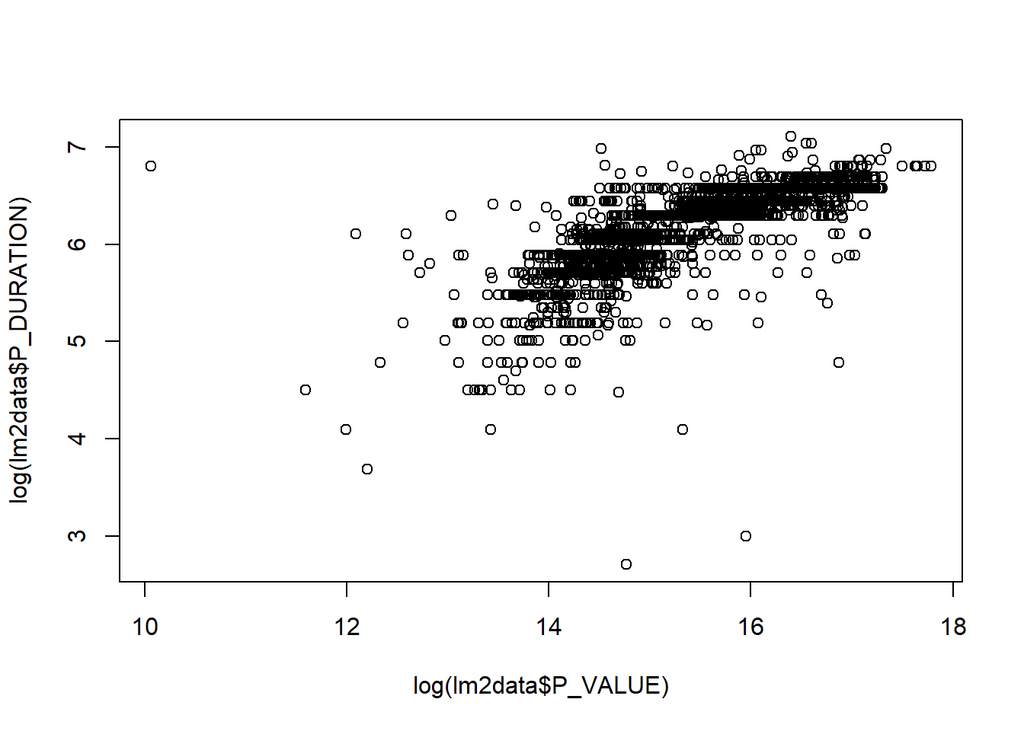

من الشكل السابق يتضح جدا العلاقة الخطية بين المتغيرين (باستخدام تحويلة اللوغاريتم) وفيما يلي قيمةالارتباط للمتغيرين باستخدام التحويلة.

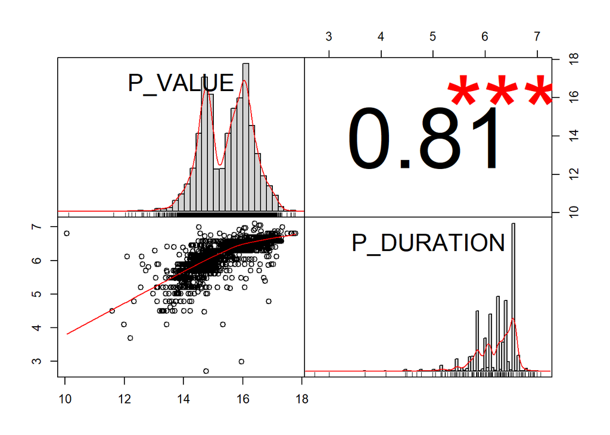

```
##
## Call:
## lm(formula = log(P_VALUE) ~ log(P_DURATION), data = lm1data)
##
## Residuals:
##     Min      1Q  Median      3Q     Max
## -6.4128 -0.2841 -0.0090  0.2284  6.4193
##
## Coefficients:
##                 Estimate Std. Error t value Pr(>|t|)
## (Intercept)      4.07050    0.11824   34.43   <2e-16 ***
## log(P_DURATION)  1.82358    0.01891   96.46   <2e-16 ***
## ---
## Signif. codes:  0 '***' 0.001 '**' 0.01 '*' 0.05 '.' 0.1 ' ' 1
##
## Residual standard error: 0.4904 on 4828 degrees of freedom
## Multiple R-squared:  0.6584, Adjusted R-squared:  0.6583
## F-statistic:  9304 on 1 and 4828 DF,  p-value: < 2.2e-16
```

|  | Estimate | Std. Error | t value | Pr(>\|t\|) |
| --- | --- | --- | --- | --- |
| (Intercept) | 4.070498 | 0.1182354 | 34.42707 | 0 |
| log(P_DURATION) | 1.823584 | 0.0189055 | 96.45794 | 0 |

| reg_name | mean_time | sd_time |
| --- | --- | --- |
| جدة | 613.0272 | 160.6681 |
| جازان | 610.1971 | 137.7964 |
| المدينة المنورة | 589.9370 | 179.6554 |
| الشرقية | 587.0455 | 160.6752 |
| الجوف | 583.0137 | 134.9246 |
| نجران | 572.8673 | 127.3550 |
| تبوك | 563.3913 | 145.4669 |
| حدود شمالية | 549.2469 | 172.2562 |
| الرياض | 531.4430 | 174.6441 |
| عسير | 528.2841 | 182.4554 |

[output cut: 6 more lines]

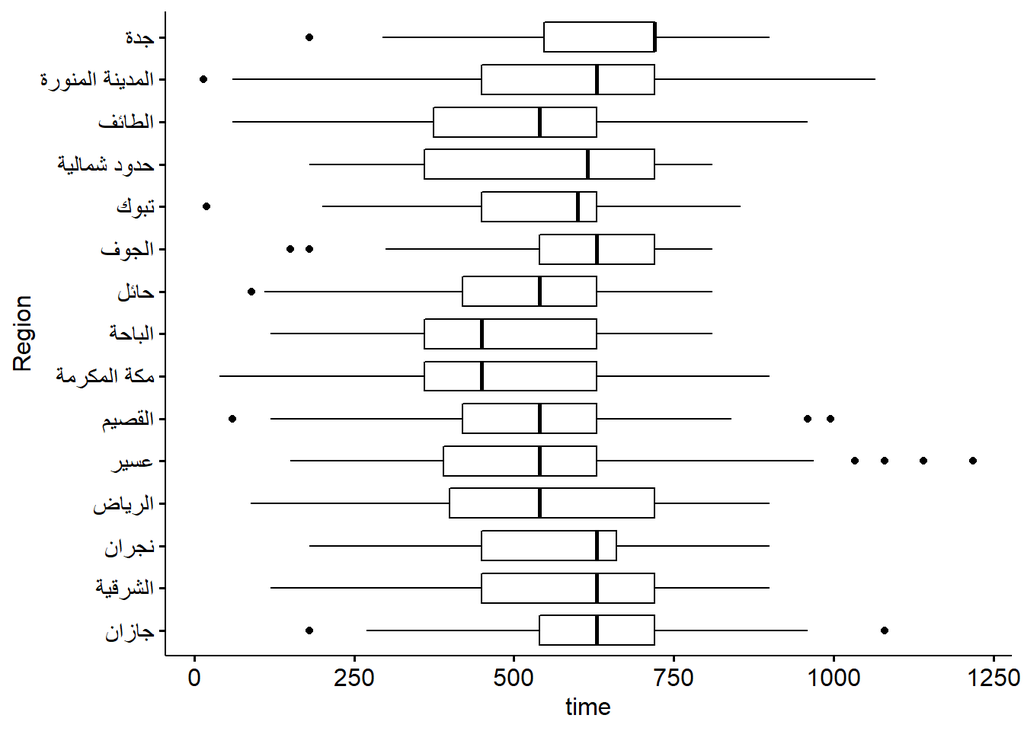

وبذلك تم تحسين نموذج الانحدار باضافة المنطقة كمتغير مفسر كما يلي:

```
##
## Call:
## lm(formula = log(P_VALUE) ~ factor(reg_name) + log(P_DURATION),
##     data = lm1data)
##
## Residuals:
##     Min      1Q  Median      3Q     Max
## -6.0573 -0.2775 -0.0198  0.2265  6.1897
##
## Coefficients:
##                                  Estimate Std. Error t value Pr(>|t|)
## (Intercept)                      4.198325   0.122611  34.241  < 2e-16 ***
## factor(reg_name)الجوف            0.155455   0.055910   2.780  0.00545 **
## factor(reg_name)الرياض          -0.051860   0.042256  -1.227  0.21978
## factor(reg_name)الشرقية          0.066119   0.044973   1.470  0.14158
## factor(reg_name)الطائف           0.141360   0.051076   2.768  0.00567 **
## factor(reg_name)القصيم          -0.109430   0.045539  -2.403  0.01630 *
## factor(reg_name)المدينة المنورة  0.036384   0.046957   0.775  0.43847
## factor(reg_name)تبوك             0.158448   0.056665   2.796  0.00519 **
## factor(reg_name)جازان            0.090807   0.047283   1.920  0.05485 .
## factor(reg_name)جدة              0.144397   0.055967   2.580  0.00991 **
## factor(reg_name)حائل            -0.119891   0.050664  -2.366  0.01800 *
## factor(reg_name)حدود شمالية      0.004472   0.066497   0.067  0.94638
## factor(reg_name)عسير            -0.089321   0.043188  -2.068  0.03868 *
## factor(reg_name)مكة المكرمة      0.007215   0.045530   0.158  0.87409
## factor(reg_name)نجران           -0.354766   0.060197  -5.893 4.04e-09 ***
## log(P_DURATION)                  1.804674   0.018946  95.253  < 2e-16 ***
## ---
## Signif. codes:  0 '***' 0.001 '**' 0.01 '*' 0.05 '.' 0.1 ' ' 1
##
## Residual standard error: 0.4806 on 4814 degrees of freedom
## Multiple R-squared:  0.6729, Adjusted R-squared:  0.6718
## F-statistic: 660.1 on 15 and 4814 DF,  p-value: < 2.2e-16
```

|  | Estimate | Std. Error | t value | Pr(>\|t\|) |
| --- | --- | --- | --- | --- |
| (Intercept) | 4.1983247 | 0.1226110 | 34.2410185 | 0.0000000 |
| factor(reg_name)الجوف | 0.1554548 | 0.0559096 | 2.7804660 | 0.0054492 |
| factor(reg_name)الرياض | -0.0518600 | 0.0422561 | -1.2272803 | 0.2197773 |
| factor(reg_name)الشرقية | 0.0661190 | 0.0449733 | 1.4701812 | 0.1415780 |
| factor(reg_name)الطائف | 0.1413595 | 0.0510764 | 2.7676081 | 0.0056685 |
| factor(reg_name)القصيم | -0.1094298 | 0.0455388 | -2.4029995 | 0.0162988 |
| factor(reg_name)المدينة المنورة | 0.0363836 | 0.0469565 | 0.7748366 | 0.4384743 |
| factor(reg_name)تبوك | 0.1584478 | 0.0566651 | 2.7962118 | 0.0051911 |
| factor(reg_name)جازان | 0.0908073 | 0.0472832 | 1.9204985 | 0.0548540 |
| factor(reg_name)جدة | 0.1443968 | 0.0559667 | 2.5800471 | 0.0099080 |
| factor(reg_name)حائل | -0.1198914 | 0.0506639 | -2.3664070 | 0.0180011 |
| factor(reg_name)حدود شمالية | 0.0044723 | 0.0664970 | 0.0672556 | 0.9463810 |
| factor(reg_name)عسير | -0.0893208 | 0.0431880 | -2.0681844 | 0.0386760 |
| factor(reg_name)مكة المكرمة | 0.0072154 | 0.0455299 | 0.1584752 | 0.8740890 |
| factor(reg_name)نجران | -0.3547662 | 0.0601969 | -5.8934303 | 0.0000000 |
| log(P_DURATION) | 1.8046742 | 0.0189461 | 95.2530008 | 0.0000000 |

### السيناريو 2: مطلوب بيانات كثيرة لتطبيقه - مطلوب شرح تفصيلي للسيناريو

### السيناريو 5:

القيم الاضافية للمشاريع بالمليون ريال علي مستوي المناطق:

| reg_name | sum_extra_value |
| --- | --- |
| الرياض | 324.7 |
| الشرقية | 169.0 |
| جازان | 142.5 |
| القصيم | 119.0 |
| المدينة المنورة | 95.1 |
| عسير | 91.7 |
| جدة | 63.2 |
| مكة المكرمة | 60.7 |
| تبوك | 55.0 |
| الجوف | 52.7 |
| الباحة | 40.4 |
| حائل | 39.3 |
| نجران | 24.9 |
| حدود شمالية | 17.1 |
| الطائف | 14.8 |
| الوكالة | 0.0 |

القيم الاضافية للمشاريع بالمليون ريال علي مستوي المقاولين:

| cont_name | sum_extra_value |
| --- | --- |
| شركة المقاول العربي | 61.7 |
| مؤسسة درة المدائن للمقاولات بالتضامن مع ش/ الدولية للبناء والتطوير | 53.3 |
| شركة بكين الإمارات الدولية للإنشاءات | 50.6 |
| مؤسسة عيد نصار العمراني | 43.6 |
| مؤسسة عبدالله مهنا الجمعان للمقاولات | 37.4 |
| مؤسسة عبدالله على السلامة | 34.7 |
| مؤسسة عبد المحسن الدرسوني للمقاولات | 31.3 |
| مؤسسة الافتكار للمقاولات | 28.9 |
| شركة العزم للتجارة والمقاولات | 28.9 |
| شركة الاعمال التطويرية المحدودة بالتضامن مع م/ التخطيط المميزة للانشاءات | 27.9 |
| مؤسسة اعمال الارياف للتجارة والمقاولات | 26.4 |
| مؤسسة محمد يوسف العجلان للمقاولات | 22.2 |
| مؤسسة التاج للتجارة والمقاولات | 22.2 |
| شركة بناء الجزيرة للمقاولات | 22.1 |
| شركة محمد وسليمان عساف العساف بالتضامن مع ش/ الاسود | 21.9 |
| مؤسسة الخليج المتطورة للمقاولات | 18.5 |
| شركة الحقيل للمقاولات | 17.6 |
| شركة الصخور السعودية للتنمية المحدودة | 17.4 |
| شركة الاعمال التطويرية المحدودة بالتضامن مع شركة التعفف للاعمال الكهربائية المحدودة | 17.4 |
| شركة الاعمال التطويرية المحدودة | 15.7 |
| مؤسسة مؤنس الشايب للمقاولات | 15.3 |
| مؤسسة الحفاوة للقاولات | 14.8 |
| مؤسسة الفارس الابيض | 14.7 |
| الشركه السعودية للتشييد | 13.8 |
| شركة البنايات العربية للمقاولات مع م/ المشرب | 13.6 |
| فرع مؤسسة سالم بالحمر بالتضامن ش/ الحقيل | 13.2 |
| شركة هاشم للمقاولات والتجارة المحدودة | 13.0 |
| شركة الراجحي للتنمية المحدودة | 12.0 |
| شركة احمد ابراهيم العضيبي للتجارة والمقاولات وشريكة | 10.9 |
| مؤسسة فالح محمد بن شايع الدوسري للمقاولات | 10.4 |

[output cut: 207 more lines]

### السيناريو 6:

الوقت الاضافي للمشاريع علي مستوي المناطق:

| reg_name | sum_extra_time |
| --- | --- |
| الرياض | 109138.0 |
| الشرقية | 61392.0 |
| جازان | 57202.0 |
| المدينة المنورة | 49754.0 |
| عسير | 38453.0 |
| جدة | 36465.0 |
| القصيم | 34221.0 |
| مكة المكرمة | 31479.5 |
| حائل | 20983.0 |
| نجران | 20579.0 |
| الجوف | 18132.0 |
| الباحة | 13172.0 |
| تبوك | 7363.0 |
| الطائف | 5233.0 |
| حدود شمالية | 5036.0 |
| الوكالة | 2208.0 |

الوقت الاضافي للمشاريع علي مستوي المقاولين:

| cont_name | sum_extra_time |
| --- | --- |
| شركة المقاول العربي | 24294.0 |
| شركة الاعمال التطويرية المحدودة بالتضامن مع م/ التخطيط المميزة للانشاءات | 19004.0 |
| مؤسسة عبدالله على السلامة | 17712.0 |
| مؤسسة عبد المحسن الدرسوني للمقاولات | 17671.0 |
| مؤسسة الافتكار للمقاولات | 12709.0 |
| شركة بكين الإمارات الدولية للإنشاءات | 12576.0 |
| شركة العزم للتجارة والمقاولات | 9745.0 |
| شركة المنير للمقاولات المتكاملة | 9503.0 |
| شركة الاعمال التطويرية المحدودة | 8623.0 |
| شركة الاعمال التطويرية المحدودة بالتضامن مع شركة التعفف للاعمال الكهربائية المحدودة | 8363.0 |
| مؤسسة اعمال الارياف للتجارة والمقاولات | 8035.0 |
| شركة الصخور السعودية للتنمية المحدودة | 7909.0 |
| مؤسسة المناظر المطورة بالتضامن مع / السليم | 6529.0 |
| مؤسسة ماجد عبدالله الراشد للمقاولات | 6345.0 |
| الشركه السعودية للتشييد | 6131.0 |
| مؤسسة درة المدائن للمقاولات بالتضامن مع ش/ الدولية للبناء والتطوير | 5797.0 |
| مؤسسة راك الجزيرة للمقاولات | 5795.0 |
| شركة سما الازدهار للمقاولات العامة | 5736.0 |
| شركة الحقيل للمقاولات | 5393.0 |
| شركة الراجحي للتنمية المحدودة | 5239.0 |
| شركة بناء الجزيرة للمقاولات | 4927.0 |
| شركة سعود الصاعدي وشركاه للمقاولات | 4783.0 |
| شركة ميلاف السعودية للمقاولات | 4591.0 |
| شركة خضوب للمقاولات | 4482.0 |
| مؤسسة عبدالله مهنا الجمعان للمقاولات | 4436.0 |
| مؤسسة درة المدائن للمقاولات بالتضامن مع شركةابناء سليمان القضيبي للمقاولات المحدودة | 4220.0 |
| مؤسسة سبا للمقاولات | 4188.0 |
| شركة المنزل الماسي المحدودة | 4115.0 |
| مؤسسة مؤنس الشايب للمقاولات | 4015.0 |
| مؤسسة الفارس الابيض | 3862.0 |

[output cut: 379 more lines]

### السيناريو 7:

| cont_name | number_projects | number_warning | warning_rate |
| --- | --- | --- | --- |
| ابراهيم محمد آل دعشوش للمقاولات | 1 | 1 | 1.00 |
| اجواد الاقصى | 1 | 1 | 1.00 |
| الوديان الماسية للمقاولات | 1 | 1 | 1.00 |
| بيارق الجنوب | 1 | 1 | 1.00 |
| سماكو | 1 | 1 | 1.00 |
| شركة ابراج طيبة للتشييد والبناء | 1 | 1 | 1.00 |
| شركة أبو كريمة للمقاولات | 2 | 2 | 1.00 |
| شركة اتحاد سين التجارية المحدودة | 2 | 2 | 1.00 |
| شركة اعمار النايفات للانشاءات ( م صالح نايف الحربي سابقا ) | 2 | 2 | 1.00 |
| شركة أعمال الهلالية للمقاولات | 1 | 1 | 1.00 |
| شركة المتكاملة الذهبية للانشاء والتعمير | 1 | 1 | 1.00 |
| شركة أهراس للمقاولات | 2 | 2 | 1.00 |
| شركة تارس للانشاءات المحدودة | 1 | 1 | 1.00 |
| شركة جمال بدران وشريكته الخليج للمقاولات | 1 | 1 | 1.00 |
| شركة دال السعودية | 1 | 1 | 1.00 |
| شركة دلتا السعودية بالتضامن مع مؤسسة دار الفراسة للمقاولات | 2 | 2 | 1.00 |
| شركة ديار القداح للمقاولات | 1 | 1 | 1.00 |
| شركة ركن أمية للمقاولات | 1 | 1 | 1.00 |
| شركة رمك للتجارة والمقاولات | 1 | 1 | 1.00 |
| شركة سما الازدهار للمقاولات العامة | 12 | 12 | 1.00 |
| شركة عمران وخالد العمران | 1 | 1 | 1.00 |
| شركة لارا العربية | 1 | 1 | 1.00 |
| شركة مباني الشام للمقاولات المتميزه | 4 | 4 | 1.00 |
| شركة مدك العالمية | 1 | 1 | 1.00 |
| شركة مسايف للمقاولات | 1 | 1 | 1.00 |
| شركة مسايف للمقاولات (مؤسسة عمرو علي الشايع سابقاً) | 5 | 5 | 1.00 |
| شركة مشاريع الوطن( مقبل ابراهيم الصاعدي) | 1 | 1 | 1.00 |
| شركة مفتاح الشرق للمقاولات بالتضامن مع ش/ اناضيم | 1 | 1 | 1.00 |
| شركة وكر الصقور للمقاولات | 1 | 1 | 1.00 |
| فرع شركة المنير للمقاولات المتكاملة | 1 | 1 | 1.00 |

[output cut: 466 more lines]

### السيناريو 9:

| cont_name | number_projects | mean_progress |
| --- | --- | --- |
| شركة المقاول العربي | 166 | 92.87 |
| مؤسسة نوادر العمران للمقاولات | 65 | 83.07 |
| شركة الراجحي للتنمية المحدودة | 56 | 97.35 |
| مؤسسة عبيد علي السلمي للمقاولات | 51 | 75.34 |
| شركة بكين الإمارات الدولية للإنشاءات | 48 | 92.09 |
| شركة ابناء سليمان القضيبي للمقاولات | 45 | 66.03 |
| شركة الصخور السعودية للتنمية المحدودة | 40 | 78.41 |
| مؤسسة عبد المحسن الدرسوني للمقاولات | 38 | 66.78 |
| شركة هاشم للمقاولات والتجارة المحدودة | 37 | 97.34 |
| مؤسسة راك الجزيرة للمقاولات | 32 | 76.36 |
| مؤسسة الحفاوة للقاولات | 31 | 86.89 |
| مؤسسة الافتكار للمقاولات | 30 | 82.53 |
| مؤسسة جزاع نحيطر الجزاع | 29 | 83.71 |
| مؤسسة محمد يوسف العجلان للمقاولات | 28 | 90.47 |
| مؤسسة مؤنس الشايب للمقاولات | 27 | 97.01 |
| مؤسسة اعمال الارياف للتجارة والمقاولات | 26 | 79.55 |
| شركة الاعمال التطويرية المحدودة | 25 | 75.56 |
| مؤسسة المشاريع الهندسية المتقدمة | 25 | 44.70 |
| شركة الانشاءات الهندسية والتقدم الصناعي (اندكو) | 24 | 91.46 |
| مؤسسة التاج للتجارة والمقاولات | 24 | 95.78 |
| شركة العزم للتجارة والمقاولات | 23 | 74.88 |
| شركة المنزل الماسي المحدودة | 23 | 28.84 |
| مؤسسة عبدالله مهنا الجمعان للمقاولات | 22 | 97.72 |
| الشركه السعودية للتشييد | 21 | 72.74 |
| مؤسسة عبدالله على السلامة | 21 | 85.54 |
| مؤسسة المنغصي للتجارة والمقاولات | 20 | 30.80 |
| مؤسسة دوانيق للتجارة والمقاولات | 20 | 59.96 |
| م/ المشاريع الهندسية الكندية بالتضامن مع ش/ جودت للمقاولات | 19 | 27.63 |
| مؤسسة بيداء العرب للصيانة والمقاولات | 19 | 97.00 |
| مؤسسة عبيد مبارك القحطاني للمقاولات العامة | 19 | 97.26 |

[output cut: 1426 more lines]

### السيناريو 10:

| reg_name | number_projects | number_projects_mashouba | percent_mashouba | number_projects_faskh | percent_faskh |
| --- | --- | --- | --- | --- | --- |
| الباحة | 152 | 19 | 12.50 | 4 | 2.63 |
| الجوف | 146 | 13 | 8.90 | 2 | 1.37 |
| الرياض | 913 | 74 | 8.11 | 18 | 1.97 |
| الشرقية | 483 | 72 | 14.91 | 17 | 3.52 |
| الطائف | 214 | 36 | 16.82 | 5 | 2.34 |
| القصيم | 431 | 46 | 10.67 | 1 | 0.23 |
| المدينة المنورة | 349 | 26 | 7.45 | 19 | 5.44 |
| الوكالة | 3 | 0 | 0.00 | 0 | 0.00 |
| تبوك | 138 | 27 | 19.57 | 7 | 5.07 |
| جازان | 340 | 28 | 8.24 | 21 | 6.18 |
| جدة | 147 | 10 | 6.80 | 14 | 9.52 |
| حائل | 225 | 17 | 7.56 | 5 | 2.22 |
| حدود شمالية | 81 | 11 | 13.58 | 0 | 0.00 |
| عسير | 697 | 41 | 5.88 | 22 | 3.16 |
| مكة المكرمة | 429 | 73 | 17.02 | 20 | 4.66 |
| نجران | 118 | 4 | 3.39 | 2 | 1.69 |

| cont_name | number_projects | number_projects_mashouba | percent_mashouba | number_projects_faskh | percent_faskh |
| --- | --- | --- | --- | --- | --- |
| مؤسسة عبيد علي السلمي للمقاولات | 51 | 14 | 27.45 | 0 | 0.00 |
| شركة ابناء سليمان القضيبي للمقاولات | 45 | 5 | 11.11 | 3 | 6.67 |
| شركة الصخور السعودية للتنمية المحدودة | 40 | 5 | 12.50 | 0 | 0.00 |
| شركة الاعمال التطويرية المحدودة | 25 | 2 | 8.00 | 0 | 0.00 |
| مؤسسة المشاريع الهندسية المتقدمة | 25 | 5 | 20.00 | 14 | 56.00 |
| شركة العزم للتجارة والمقاولات | 23 | 2 | 8.70 | 0 | 0.00 |
| الشركه السعودية للتشييد | 21 | 2 | 9.52 | 0 | 0.00 |
| م/ المشاريع الهندسية الكندية بالتضامن مع ش/ جودت للمقاولات | 19 | 14 | 73.68 | 2 | 10.53 |
| مؤسسة بن عاكف للمقاولات | 18 | 3 | 16.67 | 1 | 5.56 |
| مؤسسة مقر الخبرة للمقاولات | 16 | 2 | 12.50 | 0 | 0.00 |
| شركة اسس التعمير للمقاولات | 14 | 3 | 21.43 | 2 | 14.29 |
| شركة شمال الرياض | 14 | 6 | 42.86 | 0 | 0.00 |
| مؤسسة انوار المعالي للمقاولات | 13 | 7 | 53.85 | 0 | 0.00 |
| مؤسسة مقارب للتجارة والمقاولات | 13 | 2 | 15.38 | 6 | 46.15 |
| شركة الاخوة للمقاولات | 12 | 7 | 58.33 | 0 | 0.00 |
| مؤسسة اعمار الشريف للمقاولات | 12 | 3 | 25.00 | 1 | 8.33 |
| شركة محاور الغد للمقاولات | 11 | 2 | 18.18 | 0 | 0.00 |
| مؤسسة نماء العمران بالتضامن مع / مسفر آل تيسان | 11 | 8 | 72.73 | 1 | 9.09 |
| مؤسسة عبيد السلمي للمقاولات | 10 | 7 | 70.00 | 0 | 0.00 |
| مؤسسة يازي احمد العنزي للمقاولات | 10 | 1 | 10.00 | 0 | 0.00 |
| شركة اتحاد المملكة بالتضامن مع ش/ الحقيل | 9 | 8 | 88.89 | 0 | 0.00 |
| شركة المحور العربي المحدودة (سعود الحزيم سابقا) | 9 | 4 | 44.44 | 1 | 11.11 |
| شركة مقاول الرياض للمقاولات بالتضامن مع شركة أعمال لبب | 9 | 9 | 100.00 | 0 | 0.00 |
| مؤسسة التركي للتجارة والمقاولات | 9 | 2 | 22.22 | 4 | 44.44 |
| مؤسسة محمد القويز للمقاولات العامة | 9 | 1 | 11.11 | 0 | 0.00 |
| شركة المنير للمقاولات | 8 | 1 | 12.50 | 0 | 0.00 |
| مؤسسة صالح سعيد طيشان للتجارة والمقاولات | 8 | 1 | 12.50 | 0 | 0.00 |
| مؤسسة قبس الخليج للمقاولات | 8 | 1 | 12.50 | 0 | 0.00 |
| مؤسسة محمد عبد العزيز اليحياء للمقاولات | 8 | 1 | 12.50 | 0 | 0.00 |
| مؤسسة معالم البناء | 8 | 1 | 12.50 | 1 | 12.50 |

[output cut: 236 more lines]

### السيناريو 11:

أولا علي مستوي المناطق

| reg_name | number_projects | sum_value | number_projects_Primary | number_projects_final | number_projects_mashouba | number_projects_faskh | mean_progress |
| --- | --- | --- | --- | --- | --- | --- | --- |
| الباحة | 152 | 840.3 | 104 | 15 | 19 | 4 | 79.2 |
| الجوف | 146 | 1262.9 | 64 | 49 | 13 | 2 | 83.5 |
| الرياض | 913 | 6333.3 | 426 | 267 | 74 | 18 | 80.7 |
| الشرقية | 483 | 4169.9 | 187 | 145 | 72 | 17 | 75.4 |
| الطائف | 214 | 1434.4 | 53 | 121 | 36 | 5 | 81.0 |
| القصيم | 431 | 2643.3 | 182 | 176 | 46 | 1 | 81.8 |
| المدينة المنورة | 349 | 2856.7 | 128 | 89 | 26 | 19 | 77.4 |
| الوكالة | 3 | 227.9 | 2 | 0 | 0 | 0 | 83.3 |
| تبوك | 138 | 1183.1 | 26 | 54 | 27 | 7 | 70.4 |
| جازان | 340 | 3034.0 | 75 | 147 | 28 | 21 | 74.1 |
| جدة | 147 | 1460.0 | 48 | 21 | 10 | 14 | 68.7 |
| حائل | 225 | 1185.9 | 136 | 21 | 17 | 5 | 67.6 |
| حدود شمالية | 81 | 592.4 | 28 | 26 | 11 | 0 | 73.0 |
| عسير | 697 | 4112.2 | 401 | 177 | 41 | 22 | 79.7 |
| مكة المكرمة | 429 | 2640.7 | 182 | 119 | 73 | 20 | 73.8 |
| نجران | 118 | 658.6 | 38 | 56 | 4 | 2 | 77.7 |

ثانيا علي مستوي الادارات

| area_name | reg_name | number_projects | sum_value | number_projects_Primary | number_projects_final | number_projects_mashouba | number_projects_faskh | mean_progress |
| --- | --- | --- | --- | --- | --- | --- | --- | --- |
| الأحساء | الشرقية | 147 | 1414.6 | 35 | 59 | 28 | 13 | 77.2 |
| الأفلاج | الرياض | 46 | 243.1 | 20 | 12 | 10 | 0 | 73.3 |
| الباحة | الباحة | 97 | 508.5 | 68 | 5 | 13 | 3 | 74.8 |
| البكيرية | القصيم | 37 | 162.6 | 2 | 20 | 8 | 1 | 74.4 |
| الجوف | الجوف | 96 | 795.6 | 38 | 36 | 5 | 2 | 85.9 |
| الحدود الشمالية | حدود شمالية | 81 | 592.4 | 28 | 26 | 11 | 0 | 73.0 |
| الحوطة والحريق | الرياض | 36 | 217.9 | 2 | 30 | 3 | 1 | 93.9 |
| الخرج | الرياض | 71 | 625.5 | 2 | 64 | 1 | 1 | 88.8 |
| الدوادمي | الرياض | 118 | 446.7 | 50 | 48 | 11 | 3 | 66.9 |
| الرس | القصيم | 87 | 394.4 | 38 | 39 | 10 | 0 | 77.3 |
| الرياض | الرياض | 306 | 3193.9 | 191 | 17 | 13 | 6 | 83.1 |
| الزلفي | الرياض | 45 | 256.0 | 8 | 29 | 3 | 0 | 92.1 |
| الشرقية | الشرقية | 199 | 1874.1 | 106 | 26 | 26 | 3 | 71.4 |
| الطائف | الطائف | 214 | 1434.4 | 53 | 121 | 36 | 5 | 81.0 |
| العلا | المدينة المنورة | 44 | 262.9 | 7 | 27 | 4 | 0 | 90.1 |
| الغاط | الرياض | 15 | 82.3 | 8 | 5 | 2 | 0 | 91.7 |
| القريات | الجوف | 50 | 467.3 | 26 | 13 | 8 | 0 | 78.7 |
| القصيم | القصيم | 199 | 1322.4 | 111 | 47 | 22 | 0 | 77.1 |
| القنفذة | مكة المكرمة | 194 | 894.9 | 33 | 104 | 45 | 1 | 73.8 |
| القويعية | الرياض | 91 | 241.1 | 51 | 26 | 10 | 1 | 71.4 |
| الليث | مكة المكرمة | 104 | 596.7 | 60 | 0 | 24 | 8 | 68.9 |
| المجمعة | الرياض | 72 | 487.9 | 54 | 3 | 2 | 2 | 94.2 |
| المخواة | الباحة | 55 | 331.8 | 36 | 10 | 6 | 1 | 86.6 |
| المدينة المنورة | المدينة المنورة | 214 | 1968.3 | 105 | 21 | 11 | 18 | 74.9 |
| المذنب | القصيم | 30 | 179.4 | 8 | 21 | 0 | 0 | 95.4 |
| المشاريع المركزية | الوكالة | 3 | 227.9 | 2 | 0 | 0 | 0 | 83.3 |
| المهد | المدينة المنورة | 36 | 113.0 | 7 | 15 | 6 | 0 | 73.3 |
| النماص | عسير | 36 | 188.5 | 10 | 11 | 10 | 1 | 69.4 |
| بيشة | عسير | 153 | 971.6 | 103 | 41 | 5 | 1 | 83.4 |
| تبوك | تبوك | 138 | 1183.1 | 26 | 54 | 27 | 7 | 70.4 |
| جازان | جازان | 223 | 1992.2 | 43 | 105 | 9 | 16 | 72.9 |
| جدة | جدة | 147 | 1460.0 | 48 | 21 | 10 | 14 | 68.7 |
| حائل | حائل | 225 | 1185.9 | 136 | 21 | 17 | 5 | 67.6 |
| حفر الباطن | الشرقية | 136 | 861.8 | 46 | 60 | 18 | 0 | 79.4 |
| رجال ألمع | عسير | 38 | 173.8 | 19 | 12 | 0 | 0 | 82.0 |
| سراة عبيدة | عسير | 63 | 254.0 | 24 | 24 | 4 | 5 | 67.1 |
| شرورة | نجران | 12 | 52.6 | 8 | 2 | 1 | 1 | 77.7 |
| شقراء | الرياض | 34 | 185.3 | 7 | 4 | 12 | 1 | 60.0 |
| صبياء | جازان | 117 | 1041.8 | 32 | 42 | 19 | 5 | 76.3 |
| ظهران الجنوب | عسير | 25 | 101.8 | 19 | 5 | 0 | 1 | 91.1 |
| عسير | عسير | 267 | 1920.0 | 178 | 50 | 12 | 5 | 87.2 |
| عفيف | الرياض | 39 | 89.2 | 10 | 20 | 5 | 0 | 75.3 |
| عنيزة | القصيم | 78 | 584.6 | 23 | 49 | 6 | 0 | 96.6 |
| محايل عسير | عسير | 115 | 502.6 | 48 | 34 | 10 | 9 | 61.7 |
| مكة المكرمة | مكة المكرمة | 131 | 1149.1 | 89 | 15 | 4 | 11 | 78.0 |
| نجران | نجران | 107 | 625.4 | 30 | 54 | 3 | 2 | 77.5 |
| وادى الدواسر | الرياض | 40 | 264.4 | 23 | 9 | 2 | 3 | 88.1 |
| ينبع | المدينة المنورة | 55 | 512.5 | 9 | 26 | 5 | 1 | 79.8 |

### السيناريو 12:

| cont_name | number_projects | sum_value | number_projects_Primary | number_projects_final | number_projects_mashouba | number_projects_faskh | mean_progress | number_warning | number_warning_final |
| --- | --- | --- | --- | --- | --- | --- | --- | --- | --- |
| شركة المقاول العربي | 166 | 1826.3 | 56 | 86 | 0 | 0 | 92.9 | 24 | 3 |
| مؤسسة نوادر العمران للمقاولات | 65 | 543.9 | 31 | 28 | 0 | 0 | 83.1 | 1 | 0 |
| شركة الراجحي للتنمية المحدودة | 56 | 636.1 | 23 | 31 | 0 | 0 | 97.3 | 0 | 0 |
| مؤسسة عبيد علي السلمي للمقاولات | 51 | 555.8 | 15 | 18 | 14 | 0 | 75.3 | 24 | 17 |
| شركة بكين الإمارات الدولية للإنشاءات | 48 | 367.8 | 0 | 42 | 0 | 4 | 92.1 | 0 | 0 |
| شركة ابناء سليمان القضيبي للمقاولات | 45 | 753.0 | 9 | 18 | 5 | 3 | 66.0 | 26 | 15 |
| شركة الصخور السعودية للتنمية المحدودة | 40 | 418.0 | 9 | 19 | 5 | 0 | 78.4 | 10 | 2 |
| مؤسسة عبد المحسن الدرسوني للمقاولات | 38 | 357.6 | 17 | 0 | 0 | 0 | 66.8 | 27 | 15 |
| شركة هاشم للمقاولات والتجارة المحدودة | 37 | 547.4 | 25 | 12 | 0 | 0 | 97.3 | 3 | 2 |
| مؤسسة راك الجزيرة للمقاولات | 32 | 222.1 | 10 | 5 | 0 | 0 | 76.4 | 13 | 4 |
| مؤسسة الحفاوة للقاولات | 31 | 332.7 | 18 | 13 | 0 | 0 | 86.9 | 4 | 1 |
| مؤسسة الافتكار للمقاولات | 30 | 315.9 | 6 | 16 | 0 | 0 | 82.5 | 4 | 2 |
| مؤسسة جزاع نحيطر الجزاع | 29 | 169.2 | 24 | 5 | 0 | 0 | 83.7 | 0 | 0 |
| مؤسسة محمد يوسف العجلان للمقاولات | 28 | 229.5 | 17 | 10 | 0 | 1 | 90.5 | 2 | 0 |
| مؤسسة مؤنس الشايب للمقاولات | 27 | 354.3 | 13 | 12 | 0 | 0 | 97.0 | 7 | 2 |
| مؤسسة اعمال الارياف للتجارة والمقاولات | 26 | 223.4 | 11 | 10 | 0 | 0 | 79.5 | 4 | 2 |
| شركة الاعمال التطويرية المحدودة | 25 | 330.3 | 9 | 6 | 2 | 0 | 75.6 | 11 | 9 |
| مؤسسة المشاريع الهندسية المتقدمة | 25 | 266.9 | 1 | 0 | 5 | 14 | 44.7 | 10 | 8 |
| شركة الانشاءات الهندسية والتقدم الصناعي (اندكو) | 24 | 275.6 | 22 | 2 | 0 | 0 | 91.5 | 2 | 0 |
| مؤسسة التاج للتجارة والمقاولات | 24 | 237.4 | 10 | 13 | 0 | 0 | 95.8 | 4 | 1 |
| شركة العزم للتجارة والمقاولات | 23 | 288.2 | 9 | 2 | 2 | 0 | 74.9 | 11 | 7 |
| شركة المنزل الماسي المحدودة | 23 | 178.6 | 0 | 0 | 0 | 5 | 28.8 | 8 | 2 |
| مؤسسة عبدالله مهنا الجمعان للمقاولات | 22 | 298.6 | 5 | 12 | 0 | 0 | 97.7 | 5 | 0 |
| الشركه السعودية للتشييد | 21 | 204.7 | 6 | 4 | 2 | 0 | 72.7 | 13 | 3 |
| مؤسسة عبدالله على السلامة | 21 | 227.1 | 9 | 0 | 0 | 0 | 85.5 | 9 | 0 |
| مؤسسة المنغصي للتجارة والمقاولات | 20 | 177.4 | 4 | 0 | 0 | 8 | 30.8 | 13 | 11 |
| مؤسسة دوانيق للتجارة والمقاولات | 20 | 55.9 | 11 | 5 | 0 | 0 | 60.0 | 4 | 0 |
| م/ المشاريع الهندسية الكندية بالتضامن مع ش/ جودت للمقاولات | 19 | 195.3 | 0 | 0 | 14 | 2 | 27.6 | 11 | 10 |
| مؤسسة بيداء العرب للصيانة والمقاولات | 19 | 122.3 | 6 | 13 | 0 | 0 | 97.0 | 1 | 0 |
| مؤسسة عبيد مبارك القحطاني للمقاولات العامة | 19 | 100.9 | 17 | 2 | 0 | 0 | 97.3 | 3 | 0 |

[output cut: 1426 more lines]

## فكرة ربط عدد المشاريع المسلمة ابتدائ ونهائي بالسنوات …. جاري العمل ….

### draft for time plot graphs as ideas for year based prediction

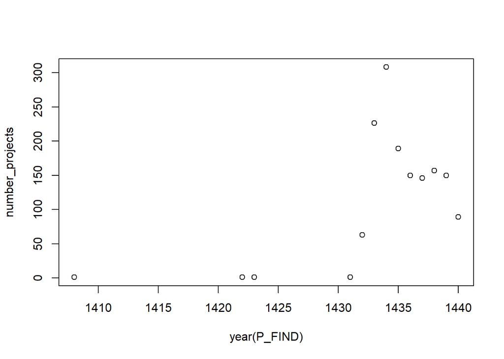

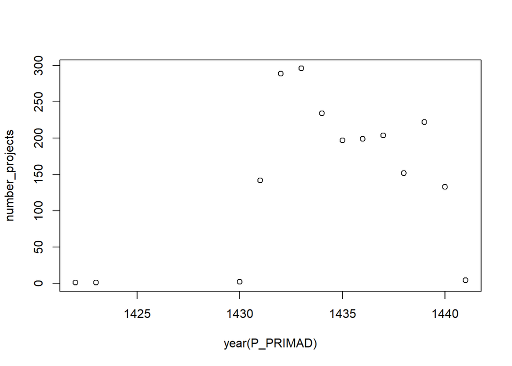

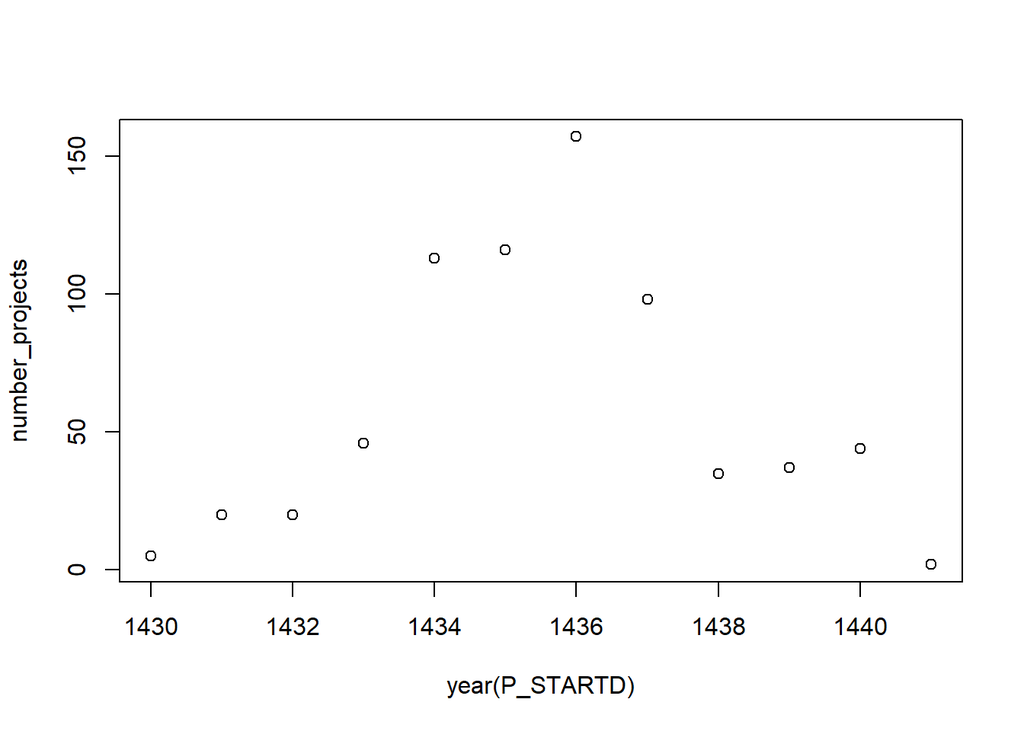

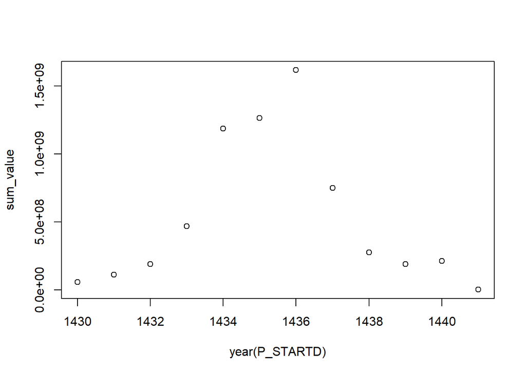